# From customer response models to a price recommendation

```python
# End-to-End Revenue Check
scored = load('scored_trips')

scored_test = (
    scored.loc[
        scored['slice'].eq('test')
    ]
    .set_index('trip_id')
)

test_trip_ids = trips.loc[
    te,
    'trip_id',
]

common_trip_ids = test_trip_ids[
    test_trip_ids.isin(scored_test.index)
]

if common_trip_ids.empty:
    REV_ERROR = np.nan

    raise ValueError(
        'scored_trips does not overlap the test window; '
        'rerun the State Model section'
    )

matched_test = (
    trips['trip_id']
    .isin(common_trip_ids)
    .to_numpy()
    & te
)

probability_columns = [
    f'p_{coverage_class}'
    for coverage_class in CLASSES
]

matched_trip_ids = trips.loc[
    matched_test,
    'trip_id',
]

probabilities = scored_test.loc[
    matched_trip_ids,
    probability_columns,
].to_numpy()

X_matched = X[matched_test]
trips_matched = trips[matched_test]
observed_prices = trips_matched[
    'price_multiplier'
].to_numpy()

state_revenue = np.zeros(
    (len(trips_matched), len(CLASSES))
)

for multiplier in np.unique(observed_prices):
    price_mask = observed_prices ==  multiplier

    state_revenue[price_mask] = revenue_by_state(
        X_matched.iloc[price_mask],
        trips_matched.iloc[price_mask],
        float(multiplier),
    )

expected_revenue = (
    probabilities
    * state_revenue
).sum(axis = 1)

observed_revenue = trips_matched[
    'pass_revenue'
].to_numpy()

assert np.isfinite(expected_revenue).all(), (
    'non-finite expected revenue in end-to-end check'
)

assert observed_revenue.sum() > 0, (
    'observed test revenue must be positive'
)

REV_ERROR = float(
    expected_revenue.sum()
    / observed_revenue.sum()
    - 1
)

revenue_summary = pd.DataFrame({
    'Measure': [
        'Total revenue',
        'Revenue per trip',
    ],
    'Expected Revenue': [
        expected_revenue.sum(),
        expected_revenue.mean(),
    ],
    'Observed Revenue': [
        observed_revenue.sum(),
        observed_revenue.mean(),
    ],
})

revenue_summary['Difference'] = (
    revenue_summary['Expected Revenue']
    - revenue_summary['Observed Revenue']
)

revenue_summary['Relative Error'] = (
    revenue_summary['Difference']
    / revenue_summary['Observed Revenue']
)

display(
    revenue_summary.style
    .hide(axis = 'index')
    .format({
        'Expected Revenue': '{:,.2f}',
        'Observed Revenue': '{:,.2f}',
        'Difference': '{:+,.2f}',
        'Relative Error': '{:+.1%}',
    })
    .bar(
        subset = ['Relative Error'],
        align = 'mid',
        color = [
            'rgba(227, 73, 72, 0.45)',
            'rgba(42, 120, 214, 0.45)',
        ],
        vmin = -0.25,
        vmax = 0.25,
    )
    .set_caption(
        f'End-to-End Test Revenue Reconciliation — '
        f'{len(expected_revenue):,} Trips'
    )
    .set_properties(**{'text-align': 'left'})
    .set_table_styles(TABLE_STYLES)
)

bootstrap_rng = np.random.default_rng(0)

bootstrap_errors = np.empty(2000)

for iteration in range(len(bootstrap_errors)):
    sample = bootstrap_rng.integers(
        0,
        len(expected_revenue),
        len(expected_revenue),
    )

    bootstrap_errors[iteration] = (
        expected_revenue[sample].sum()
        / observed_revenue[sample].sum()
        - 1
    )

REV_ERROR_LOWER, REV_ERROR_UPPER = np.percentile(
    bootstrap_errors,
    [2.5, 97.5],
)

uncertainty_summary = pd.DataFrame({
    'Aggregate Error': [REV_ERROR],
    'Lower Bound': [REV_ERROR_LOWER],
    'Upper Bound': [REV_ERROR_UPPER],
    'Bootstrap Replicates': [
        len(bootstrap_errors)
    ],
    'Resampling Unit': ['Trip'],
})

display(
    uncertainty_summary.style
    .hide(axis = 'index')
    .format({
        'Aggregate Error': '{:+.1%}',
        'Lower Bound': '{:+.1%}',
        'Upper Bound': '{:+.1%}',
        'Bootstrap Replicates': '{:,.0f}',
    })
    .set_caption(
        'Trip-Level Bootstrap Interval for Aggregate Revenue Error'
    )
    .set_properties(**{'text-align': 'left'})
    .set_properties(
        subset = ['Aggregate Error'],
        **{
            'color': ACCENT,
            'font-weight': 'bold',
        },
    )
    .set_table_styles(TABLE_STYLES)
)

reconciliation_data = trips_matched.assign(
    expected_revenue = expected_revenue,
    observed_revenue = observed_revenue,
    account_type = np.where(
        trips_matched['is_business'],
        'Business',
        'Consumer',
    ),
)

by_price = (
    reconciliation_data
    .groupby('price_multiplier')
    .agg(
        Trips = ('trip_id', 'size'),
        Expected_Revenue = (
            'expected_revenue',
            'sum',
        ),
        Observed_Revenue = (
            'observed_revenue',
            'sum',
        ),
    )
    .reset_index()
    .rename(columns = {
        'price_multiplier': 'Group',
        'Expected_Revenue': 'Expected Revenue',
        'Observed_Revenue': 'Observed Revenue',
    })
)

by_price.insert(
    0,
    'Dimension',
    'Observed Price',
)

by_price['Group'] = by_price['Group'].map(
    lambda value: f'{value:.2f}'
)

by_account_type = (
    reconciliation_data
    .groupby('account_type')
    .agg(
        Trips = ('trip_id', 'size'),
        Expected_Revenue = (
            'expected_revenue',
            'sum',
        ),
        Observed_Revenue = (
            'observed_revenue',
            'sum',
        ),
    )
    .reset_index()
    .rename(columns = {
        'account_type': 'Group',
        'Expected_Revenue': 'Expected Revenue',
        'Observed_Revenue': 'Observed Revenue',
    })
)

by_account_type.insert(
    0,
    'Dimension',
    'Account Type',
)

revenue_breakdown = pd.concat(
    [
        by_price,
        by_account_type,
    ],
    ignore_index = True,
)

revenue_breakdown['Revenue Error'] = (
    revenue_breakdown['Expected Revenue']
    / revenue_breakdown['Observed Revenue']
    - 1
)

display(
    revenue_breakdown.style
    .hide(axis = 'index')
    .format({
        'Trips': '{:,.0f}',
        'Expected Revenue': '{:,.0f}',
        'Observed Revenue': '{:,.0f}',
        'Revenue Error': '{:+.1%}',
    })
    .bar(
        subset = ['Revenue Error'],
        align = 'mid',
        color = [
            'rgba(227, 73, 72, 0.45)',
            'rgba(42, 120, 214, 0.45)',
        ],
        vmin = -0.25,
        vmax = 0.25,
    )
    .set_caption(
        'Revenue Reconciliation by Price and Account Type'
    )
    .set_properties(**{'text-align': 'left'})
    .set_table_styles(TABLE_STYLES)
)
```

End-to-End Test Revenue Reconciliation — 18,472 Trips

| Measure | Expected Revenue | Observed Revenue | Difference | Relative Error |
| --- | --- | --- | --- | --- |
| Total revenue | 1,040,615.39 | 1,015,445.75 | +25,169.64 | +2.5% |
| Revenue per trip | 56.33 | 54.97 | +1.36 | +2.5% |

Trip-Level Bootstrap Interval for Aggregate Revenue Error

| Aggregate Error | Lower Bound | Upper Bound | Bootstrap Replicates | Resampling Unit |
| --- | --- | --- | --- | --- |
| +2.5% | +1.7% | +3.3% | 2,000 | Trip |

Revenue Reconciliation by Price and Account Type

| Dimension | Group | Trips | Expected Revenue | Observed Revenue | Revenue Error |
| --- | --- | --- | --- | --- | --- |
| Observed Price | 0.95 | 946 | 50,332 | 49,129 | +2.4% |
| Observed Price | 1.00 | 16,611 | 934,814 | 914,545 | +2.2% |
| Observed Price | 1.10 | 915 | 55,469 | 51,772 | +7.1% |
| Account Type | Business | 10,492 | 435,967 | 425,636 | +2.4% |
| Account Type | Consumer | 7,980 | 604,649 | 589,809 | +2.5% |

## 6 · The Revenue Curve

**Purpose:** Provides a deterministic preview of modeled revenue across the candidate-price range by combining each forward-panel trip’s final State Model scenario probabilities with its state-specific revenue values. The forward-panel population (the most recent 12 months) and its observed seasonal and macroeconomic characteristics remain fixed; future uncertainty is introduced later in the 12-month simulation.

**Design Notes:**

1. **Trip-Level Calculation.** Expected revenue is calculated separately for every trip and then aggregated: $$ \widehat{R}(m) = \sum_i\sum_s \widehat{P}_i(s\mid m)\, \widehat{R}_i(s,m) $$

   where:
   - \(i\) identifies a trip.
   - \(s\) identifies a coverage state.
   - \(m\) is the candidate price multiplier.
   - \(\widehat{P}_i(s\mid m)\) is trip \(i\)’s final calibrated probability of state \(s\) at price \(m\).
   - \(\widehat{R}_i(s,m)\) is trip \(i\)’s modeled revenue under state \(s\) at the same price.

   Each trip’s probability vector is multiplied by its own state-revenue vector before aggregation. This preserves the relationship between predicted behavior and revenue exposure.
2. **Consistent Model Inputs.** Every candidate price uses:
   - The final State Model scorer
   - The fitted day- and line-coverage components
   - The state-specific revenue rules from Section 5
   - The same fixed forward-panel population

   Price is the only scenario input changed across the curve.
3. **Deterministic Preview.** The curve is a model-based scenario calculation rather than the final forecast.
   - It does not simulate future macroeconomic paths, trip-volume uncertainty, correlated behavioral outcomes, or sampling variation.
   - It holds the forward-panel population’s month, macroeconomic, customer, and trip characteristics fixed.
   - The 12-month simulation adds the forward-looking uncertainty required for the final revenue estimates.
4. **Depth Assumption.** This preview uses `depth_scale = 1.00`, representing the magnitude estimated from the reconstructed partial-coverage labels.
   - The stronger day-reduction sensitivity from Section 4 is evaluated separately in the simulation.
   - The two cases are sensitivity scenarios, not corrected and uncorrected truth or statistical bounds.
   - The depth-sensitivity factor applies only to day-reduction depth; line coverage remains unchanged.
5. **Candidate-Price Range.** Each trip is scored from a 0.90 to 1.20 price multiplier.
   - This is the permitted scenario range, not a claim that every price was historically observed across the complete customer population.
   - Historical price variation was concentrated in particular regions and periods.
   - Applying every candidate price to the fixed forward-panel population is therefore a counterfactual modeling exercise.
6. **Curve Validation.** The completed curve is checked for:
   - Finite, nonnegative revenue at every candidate price
   - Unexpected discontinuities or reversals
   - Sensitivity to the spacing of the price grid
   - Consistency between the State Model probabilities and revenue values used at each price

   Small slope changes or plateaus may result from probability calibration and the rounding of predicted covered days and lines. These are not automatically treated as model failures.
7. **Boundary Interpretation.** If modeled revenue is highest at the 1.20 multiplier and remains increasing at that point:
   - 1.20 is the best evaluated price within the approved candidate range.
   - The study does not identify an interior optimum.
   - The result does not establish that 1.20 is the true revenue-maximizing price.
   - The model provides no basis for recommending a price above the approved ceiling.

**Observations:**

1. The best evaluated price within the candidate range is **1.20**.
2. Modeled revenue at the standard price is **$2,956,579**, compared with **$3,317,045** at the best evaluated price.
3. The corresponding modeled increase is **$360,466**, or **12.2%**.
4. At the upper boundary, modeled revenue is **still increasing**.
5. The curve contains **0** unexpected direction reversals and **0** material discontinuities.
6. The curve is evaluated at the 13 exported scenario prices, the same grid the 12-month simulation uses.
7. This deterministic preview uses the as-fitted response and rises to the 1.20 boundary. The full 12-month simulation's joint stronger-response case turns over at 1.15 (Section 5); the preview reflects only the as-fitted case and is not the study's recommendation.

Deterministic Forward-Panel Revenue Preview (USD)

| Price Multiplier | Revenue | Change vs. Standard | Incremental Revenue |
| --- | --- | --- | --- |
| 0.900 | 2,735,955 | -7.5% | -220,623 |
| 0.925 | 2,792,857 | -5.5% | -163,721 |
| 0.950 | 2,848,898 | -3.6% | -107,680 |
| 0.975 | 2,904,083 | -1.8% | -52,495 |
| 1.000 | 2,956,579 | +0.0% | +0 |
| 1.025 | 2,994,157 | +1.3% | +37,578 |
| 1.050 | 3,047,134 | +3.1% | +90,556 |
| 1.075 | 3,099,623 | +4.8% | +143,044 |
| 1.100 | 3,150,623 | +6.6% | +194,045 |
| 1.125 | 3,197,192 | +8.1% | +240,613 |
| 1.150 | 3,241,448 | +9.6% | +284,870 |
| 1.175 | 3,279,308 | +10.9% | +322,729 |
| 1.200 | 3,317,045 | +12.2% | +360,466 |

Deterministic Revenue-Curve Summary

| Best Evaluated Price | Standard Revenue | Best Revenue | Revenue Lift | Declining Steps | Direction Reversals | Large Jumps | Curve Status |
| --- | --- | --- | --- | --- | --- | --- | --- |
| 1.200 | 2,956,579 | 3,317,045 | +12.2% | 0 | 0 | 0 | Still increasing at upper boundary |

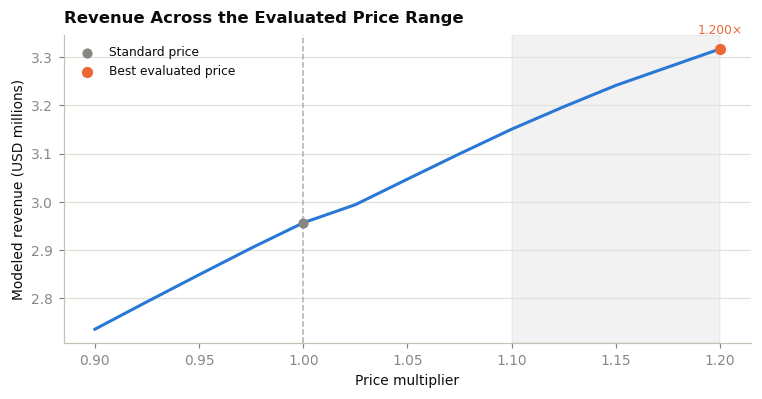

```python
# Build Deterministic Revenue Curve
scenario_probabilities = load(
    'sim_prob_scenarios'
)

scenario_probabilities = scenario_probabilities.loc[
    scenario_probabilities[
        'response_scenario'
    ].eq('base')
].copy()

scenario_probabilities['price_multiplier'] = (
    scenario_probabilities[
        'price_multiplier'
    ].round(4)
)

CURVE_GRID = np.sort(
    scenario_probabilities[
        'price_multiplier'
    ].unique()
)

forward_mask = (
    trips['month']
    >=  trips['month'].max() - 11
).to_numpy()

forward_trip_ids = trips.loc[
    forward_mask,
    'trip_id',
]

common_trip_ids = forward_trip_ids[
    forward_trip_ids.isin(
        scenario_probabilities[
            'trip_id'
        ].unique()
    )
]

if common_trip_ids.empty:
    raise ValueError(
        'sim_prob_scenarios does not overlap the forward panel'
    )

matched_forward = (
    trips['trip_id']
    .isin(common_trip_ids)
    .to_numpy()
    & forward_mask
)

matched_trip_ids = trips.loc[
    matched_forward,
    'trip_id',
].to_numpy()

probability_columns = [
    f'p_{coverage_class}'
    for coverage_class in CLASSES
]

probability_index = (
    scenario_probabilities
    .set_index([
        'price_multiplier',
        'trip_id',
    ])
    .sort_index()
)

curve_rows = []

for multiplier in CURVE_GRID:
    probabilities = (
        probability_index
        .loc[
            round(float(multiplier), 4),
            probability_columns,
        ]
        .reindex(matched_trip_ids)
        .to_numpy()
    )

    if not np.isfinite(probabilities).all():
        raise ValueError(
            f'missing scenario probabilities at '
            f'{multiplier:.4f}'
        )

    state_revenue = revenue_by_state(
        X[matched_forward],
        trips[matched_forward],
        float(multiplier),
    )

    curve_rows.append({
        'Price Multiplier': multiplier,
        'Revenue': float(
            (
                state_revenue
                * probabilities
            ).sum()
        ),
    })

curve = (
    pd.DataFrame(curve_rows)
    .set_index('Price Multiplier')
)

standard_revenue = curve.loc[
    1.0,
    'Revenue',
]

curve['Change vs. Standard'] = (
    curve['Revenue']
    / standard_revenue
    - 1
)

curve['Incremental Revenue'] = (
    curve['Revenue']
    - standard_revenue
)

curve_display = (
    curve
    .reset_index()
)

display(
    curve_display.style
    .hide(axis = 'index')
    .format({
        'Price Multiplier': '{:.3f}',
        'Revenue': '{:,.0f}',
        'Change vs. Standard': '{:+.1%}',
        'Incremental Revenue': '{:+,.0f}',
    })
    .bar(
        subset = ['Change vs. Standard'],
        align = 'mid',
        color = [
            'rgba(227, 73, 72, 0.45)',
            'rgba(42, 120, 214, 0.45)',
        ],
        vmin = -0.10,
        vmax = 0.25,
    )
    .set_caption(
        'Deterministic Forward-Panel Revenue Preview (USD)'
    )
    .set_properties(**{'text-align': 'left'})
    .set_table_styles(TABLE_STYLES)
)

best_price = float(
    curve['Revenue'].idxmax()
)

best_revenue = float(
    curve.loc[
        best_price,
        'Revenue',
    ]
)

revenue_steps = (
    curve['Revenue']
    .diff()
    .dropna()
    .to_numpy()
)

declining_steps = int(
    (revenue_steps < 0).sum()
)

nonzero_directions = np.sign(
    revenue_steps[
        np.abs(revenue_steps) > 1e-9
    ]
)

direction_reversals = int(
    (
        nonzero_directions[1:]
        !=  nonzero_directions[:-1]
    ).sum()
)

median_step = np.median(
    np.abs(revenue_steps)
)

large_jumps = (
    int(
        (
            np.abs(revenue_steps)
            > 3 * median_step
        ).sum()
    )
    if median_step > 0
    else 0
)

at_upper_boundary = bool(
    np.isclose(
        best_price,
        CURVE_GRID[-1],
    )
)

curve_summary = pd.DataFrame({
    'Best Evaluated Price': [best_price],
    'Standard Revenue': [standard_revenue],
    'Best Revenue': [best_revenue],
    'Revenue Lift': [
        best_revenue
        / standard_revenue
        - 1
    ],
    'Declining Steps': [declining_steps],
    'Direction Reversals': [direction_reversals],
    'Large Jumps': [large_jumps],
    'Curve Status': [
        (
            'Still increasing at upper boundary'
            if at_upper_boundary
            else 'Interior turnover observed'
        )
    ],
})

display(
    curve_summary.style
    .hide(axis = 'index')
    .format({
        'Best Evaluated Price': '{:.3f}',
        'Standard Revenue': '{:,.0f}',
        'Best Revenue': '{:,.0f}',
        'Revenue Lift': '{:+.1%}',
        'Declining Steps': '{:,.0f}',
        'Direction Reversals': '{:,.0f}',
        'Large Jumps': '{:,.0f}',
    })
    .set_caption(
        'Deterministic Revenue-Curve Summary'
    )
    .set_properties(**{'text-align': 'left'})
    .set_properties(
        subset = ['Best Evaluated Price'],
        **{
            'color': ACCENT,
            'font-weight': 'bold',
        },
    )
    .set_table_styles(TABLE_STYLES)
)

fig, ax = plt.subplots(
    figsize = (7, 3.7),
)

revenue_millions = (
    curve['Revenue']
    / 1e6
)

ax.plot(
    curve.index,
    revenue_millions,
    color = ACCENT,
    linewidth = 2,
)

ax.scatter(
    [1.0],
    [standard_revenue / 1e6],
    color = MUTED,
    s = 32,
    zorder = 3,
    label = 'Standard price',
)

ax.scatter(
    [best_price],
    [best_revenue / 1e6],
    color = ACCENT2,
    s = 40,
    zorder = 4,
    label = 'Best evaluated price',
)

ax.axvline(
    1.0,
    color = MUTED,
    linestyle = '--',
    linewidth = 1,
    alpha = 0.65,
)

ax.axvspan(
    1.10,
    1.20,
    color = INK,
    alpha = 0.05,
)

ax.annotate(
    f'{best_price:.3f}×',
    xy = (
        best_price,
        best_revenue / 1e6,
    ),
    xytext = (0, 10),
    textcoords = 'offset points',
    ha = 'center',
    color = ACCENT2,
    fontsize = 8,
)

ax.set(
    xlabel = 'Price multiplier',
    ylabel = 'Modeled revenue (USD millions)',
)

ax.set_title(
    'Revenue Across the Evaluated Price Range',
    loc = 'left',
    fontweight = 'bold',
    pad = 8,
)

ax.grid(
    axis = 'y',
    color = GRIDLINE,
    linewidth = 0.8,
)

ax.legend(
    frameon = False,
    fontsize = 8,
)

plt.tight_layout()
plt.show()
```

## 7 · Model Outputs and Simulation Handoff

**Purpose:** Publishes the trip-level magnitude diagnostics, state-specific revenue values, the deterministic revenue preview, and model metadata used for reporting and the 12-month simulation.

**Design Notes:**

1. **Exported Artifacts.**

   | Artifact | Grain | Role |
   | --- | --- | --- |
   | `trip_magnitudes` | One row per trip at its observed price | Auditable record of predicted day and line coverage |
   | `revenue_by_state` | One row per trip and candidate price (reported depth only) | Full-book state revenue used by the deterministic preview and §04 |
   | `sim_revenue_scenarios` | One row per forward-panel trip, candidate price, and depth scenario | The state-revenue table the 12-month simulation loads |
   | `deterministic_revenue_curve` | One row per candidate price | Stores the deterministic revenue preview from Section 6 |
   | `magnitude_meta` | One row per metadata field | Documents assumptions, coefficients, sensitivities, and the revenue error |

**Observations:**

```python
# Export Magnitude-Model Results
mag = trips[[
    'trip_id',
    'account_id',
    'month',
    'price_multiplier',
]].copy()

mag['pred_day_coverage'] = predict_coverage(
    day_base,
    day_theta,
    X,
    trips,
)

mag['pred_line_coverage'] = predict_coverage(
    line_base,
    np.zeros(2),
    X,
    trips,
)

revenue_frames = []

for multiplier in GRID:
    state_revenue = revenue_by_state(
        X,
        trips,
        float(multiplier),
    )

    revenue_frames.append(
        pd.DataFrame({
            'trip_id': trips[
                'trip_id'
            ].to_numpy(),
            'price_multiplier': float(multiplier),
            **{
                f'rev_{coverage_class}':
                    state_revenue[:, i]
                for i, coverage_class
                in enumerate(CLASSES)
            },
        })
    )

revenue_by_state_table = pd.concat(
    revenue_frames,
    ignore_index = True,
)

meta = pd.DataFrame({
    'key': [
        'depth_bias',
        'revenue_error',
        'day_price_coef',
        'line_price_coef',
        'line_price_coef_used',
    ],
    'value': [
        DEPTH_BIAS,
        REV_ERROR,
        float(day_theta[0]),
        float(line_theta[0]),
        0.0,
    ],
})

meta_display = pd.DataFrame({
    'Parameter': [
        'Stronger-depth multiplier',
        'End-to-end revenue error',
        'Day-coverage price coefficient',
        'Estimated line-price coefficient',
        'Line-price coefficient used',
    ],
    'Value': [
        f'{DEPTH_BIAS:.2f}×',
        f'{REV_ERROR:+.1%}',
        f'{day_theta[0]:+.3f}',
        f'{line_theta[0]:+.3f}',
        '0.000',
    ],
    'Interpretation': [
        'Applied in the stronger-depth sensitivity',
        'Measured on held-out trips',
        'Used in production revenue calculations',
        'Retained for diagnostic reporting',
        'Constraint-sensitive price term excluded',
    ],
})

display(
    meta_display.style
    .hide(axis = 'index')
    .set_caption('Magnitude-Model Configuration')
    .set_properties(**{'text-align': 'left'})
    .set_properties(
        subset = ['Value'],
        **{
            'color': ACCENT,
            'font-weight': 'bold',
        },
    )
    .set_table_styles(TABLE_STYLES)
)

if not np.isfinite(DEPTH_BIAS):
    raise ValueError(
        'a finite depth-bias multiplier is required '
        'for the stronger-depth scenario'
    )

probability_scenarios = load(
    'sim_prob_scenarios'
)

SIM_GRID = np.sort(
    probability_scenarios[
        'price_multiplier'
    ].round(4).unique()
)

forward_mask = (
    trips['month']
    >=  trips['month'].max() - 11
).to_numpy()

X_forward = X[forward_mask]
trips_forward = trips[forward_mask]
forward_trip_ids = trips_forward[
    'trip_id'
].to_numpy()

scenario_frames = []

# Mirror of the stronger depth case below the fitted depth: the scenario tool's
# "Lower" sensitivity setting. No diagnostic motivates it; it shows the other direction.
LOWER_DEPTH_BIAS = 2.0 - DEPTH_BIAS
assert LOWER_DEPTH_BIAS > 0, 'lower depth scale must stay positive'

for depth_scale, scenario_name in [
    (1.0, 'reported'),
    (LOWER_DEPTH_BIAS, 'lower'),
    (DEPTH_BIAS, 'stronger'),
]:
    for multiplier in SIM_GRID:
        state_revenue = revenue_by_state(
            X_forward,
            trips_forward,
            float(multiplier),
            depth_scale = depth_scale,
        )

        scenario_frames.append(
            pd.DataFrame({
                'trip_id': forward_trip_ids,
                'price_multiplier': float(multiplier),
                'depth_scenario': scenario_name,
                **{
                    f'rev_{coverage_class}':
                        state_revenue[:, i]
                    for i, coverage_class
                    in enumerate(CLASSES)
                },
            })
        )

sim_revenue_scenarios = pd.concat(
    scenario_frames,
    ignore_index = True,
)

probability_grid = set(
    probability_scenarios[
        'price_multiplier'
    ].round(4)
)

revenue_grid = set(
    sim_revenue_scenarios[
        'price_multiplier'
    ].round(4)
)

assert probability_grid ==  revenue_grid, (
    'probability and revenue scenario grids do not match'
)

assert (
    sim_revenue_scenarios[
        ['rev_null', 'rev_partial', 'rev_full']
    ]
    .notna()
    .all()
    .all()
), 'missing values in simulation revenue scenarios'

assert (
    sim_revenue_scenarios[
        ['rev_null', 'rev_partial', 'rev_full']
    ]
    .ge(0)
    .all()
    .all()
), 'negative values in simulation revenue scenarios'

deterministic_revenue_curve = (
    curve
    .reset_index()
    .rename(columns = {
        'Price Multiplier': 'price_multiplier',
        'Revenue': 'revenue',
        'Change vs. Standard': 'vs_standard',
        'Incremental Revenue': 'incremental_revenue',
    })
)

export_summary = save_tables(
    {
        'trip_magnitudes': mag,
        'revenue_by_state': revenue_by_state_table,
        'sim_revenue_scenarios': sim_revenue_scenarios,
        'deterministic_revenue_curve':
            deterministic_revenue_curve,
        'magnitude_meta': meta,
    },
    with_cols = True,
)

export_summary = (
    export_summary
    .rename_axis('File')
    .reset_index()
    .rename(columns = {
        'rows': 'Rows',
        'cols': 'Columns',
    })
)

display(
    export_summary.style
    .hide(axis = 'index')
    .format({
        'Rows': '{:,.0f}',
        'Columns': '{:,.0f}',
    })
    .set_caption('Exported Magnitude-Model Tables')
    .set_properties(**{'text-align': 'left'})
    .set_table_styles(TABLE_STYLES)
)
```

Magnitude-Model Configuration

| Parameter | Value | Interpretation |
| --- | --- | --- |
| Stronger-depth multiplier | 1.04× | Applied in the stronger-depth sensitivity |
| End-to-end revenue error | +2.5% | Measured on held-out trips |
| Day-coverage price coefficient | -3.336 | Used in production revenue calculations |
| Estimated line-price coefficient | -1.500 | Retained for diagnostic reporting |
| Line-price coefficient used | 0.000 | Constraint-sensitive price term excluded |

Exported Magnitude-Model Tables

| File | Rows | Columns |
| --- | --- | --- |
| trip_magnitudes.parquet | 94,579 | 6 |
| revenue_by_state.parquet | 1,229,527 | 5 |
| sim_revenue_scenarios.parquet | 2,047,500 | 6 |
| deterministic_revenue_curve.parquet | 13 | 4 |
| magnitude_meta.parquet | 5 | 2 |

# 03 · The 12-Month Simulation

**Purpose:** The State and Magnitude Models estimate what happens on an individual trip. The simulation translates those trip-level relationships into a distribution of 12-month roaming revenue at each candidate price. It answers how much revenue could result and how widely that result could vary under the modeled sources of uncertainty.

1. **Why simulation is required**
   - A single expected-value calculation summarizes the center of the modeled outcome but does not describe its potential variation.
   - Reporting only a point estimate would conceal the effects of shared economic and market conditions.
   - The simulation repeatedly draws the modeled inputs and trip outcomes, producing a revenue distribution for each candidate price.

**Sources of uncertainty**

| Source | Dependence structure | Why it matters |
| --- | --- | --- |
| Macroeconomic path | Shared across the customer book and correlated over time | Changes aggregate international-travel volume |
| Market-share change | Shared across the customer book | Changes the share of international travel retained by the company |
| Trip and coverage-state realization | Independent by trip, conditional on the shared inputs | Determines which projected trips occur and which coverage state each trip enters |

2. **Shared shocks are essential to the revenue distribution**
   - Macroeconomic and market-share draws are made once per iteration and applied across the customer book.
   - This allows favorable or unfavorable conditions to affect many accounts simultaneously.
   - Drawing every outcome independently would allow positive and negative results to cancel excessively, understating aggregate uncertainty.
   - Trip occurrence and coverage state are drawn independently after conditioning on the shared inputs.
   - Multiple trips belonging to the same account do not receive an additional account-level behavioral correlation. This is a simplifying assumption of the simulation.
3. **Interpretation of the simulated distribution**
   - The resulting distribution measures variability under the fitted models and specified simulation assumptions.
   - It is not a complete forecast interval for every way the revenue estimate could be wrong.
   - Model coefficients, calibration mappings, regional-response sensitivities, and synthetic data-generating assumptions remain fixed within each scenario.
   - Selected forms of model risk are examined through separate sensitivity cases rather than stochastic parameter draws.
4. **Two model-risk sensitivities reduce projected revenue at higher prices**
   - The State Model’s regional holdout motivates a stronger price-response sensitivity.
   - The Magnitude Model’s partial-label diagnostic motivates a stronger day-reduction sensitivity.
   - Both sensitivities reduce modeled revenue at higher prices, but neither is treated as a correction to known truth or a statistical bound.

   | Case | Price response | Day-reduction depth | Interpretation |
   | --- | --- | --- | --- |
   | Fitted case | `response_scale = 1.00` | `day_depth_scale = 1.00` | Uses the fitted State and Magnitude Model responses |
   | Combined stronger-response sensitivity | Regional response sensitivity | Stronger day-depth sensitivity | Tests the recommendation under stronger movement away from coverage and deeper day reductions |

   - Every candidate price is evaluated under both cases.
   - The recommendation is compared across the two cases and anchored to the combined stronger-response sensitivity.
   - This sensitivity is intentionally more adverse for higher-price revenue, but it is not presented as a guaranteed conservative outcome.
5. **Scope**
   - The simulation estimates roaming-pass revenue over the next 12 months.
   - Wireless churn (customers leaving the carrier) is outside the scope of this study and is not modeled.
   - The simulation does not estimate customer-lifetime-value effects, broader wireless-service revenue, or other company-level consequences of a price change.
   - Final results should therefore be interpreted as roaming-revenue estimates rather than total financial impact.

```python
# Load Simulation Inputs
trips = load_trips(with_macro = False)
macro = load('macro')
scored = load('scored_trips')
prob_scen = load('sim_prob_scenarios')
rev_scen = load('sim_revenue_scenarios')

model_meta = (
    load('model_meta')
    .set_index('key')['value']
)

mag_meta = (
    load('magnitude_meta')
    .set_index('key')['value']
)

probability_grid = np.sort(
    prob_scen[
        'price_multiplier'
    ].round(4).unique()
)

revenue_grid = np.sort(
    rev_scen[
        'price_multiplier'
    ].round(4).unique()
)

if not np.array_equal(
    probability_grid,
    revenue_grid,
):
    raise ValueError(
        'probability and revenue scenario grids do not match'
    )

GRID = revenue_grid

RESPONSE_RATIO = float(
    model_meta.get(
        'response_ratio',
        1.0,
    )
)

DEPTH_BIAS = float(
    mag_meta.get(
        'depth_bias',
        1.0,
    )
)

if not np.isfinite(RESPONSE_RATIO):
    raise ValueError(
        'response ratio must be finite'
    )

if not np.isfinite(DEPTH_BIAS):
    raise ValueError(
        'depth-bias multiplier must be finite'
    )

input_summary = pd.DataFrame({
    'Input': [
        'Candidate price range',
        'Candidate price levels',
        'Response sensitivity',
        'Depth sensitivity',
        'Trip records',
        'Probability-scenario rows',
        'Revenue-scenario rows',
    ],
    'Value': [
        f'{GRID[0]:.3f}–{GRID[-1]:.3f}',
        f'{len(GRID):,}',
        f'{RESPONSE_RATIO:.2f}×',
        f'{DEPTH_BIAS:.2f}×',
        f'{len(trips):,}',
        f'{len(prob_scen):,}',
        f'{len(rev_scen):,}',
    ],
    'Source': [
        'Aligned scenario grids',
        'Aligned scenario grids',
        'State Model',
        'Magnitude Model',
        'Trip data',
        'State Model export',
        'Magnitude Model export',
    ],
})

display(
    input_summary.style
    .hide(axis = 'index')
    .set_caption('Revenue-Simulation Inputs')
    .set_properties(**{'text-align': 'left'})
    .set_properties(
        subset = ['Value'],
        **{
            'color': ACCENT,
            'font-weight': 'bold',
        },
    )
    .set_table_styles(TABLE_STYLES)
)
```

Revenue-Simulation Inputs

| Input | Value | Source |
| --- | --- | --- |
| Candidate price range | 0.900–1.200 | Aligned scenario grids |
| Candidate price levels | 13 | Aligned scenario grids |
| Response sensitivity | 1.76× | State Model |
| Depth sensitivity | 1.04× | Magnitude Model |
| Trip records | 94,579 | Trip data |
| Probability-scenario rows | 2,047,500 | State Model export |
| Revenue-scenario rows | 2,047,500 | Magnitude Model export |

## 1 · Building the Forward Year

**Purpose:** Constructs a forward 12-month panel of candidate trip profiles from the most recent historical year. Each simulation iteration determines which of those profiles occur under the drawn macroeconomic, market-share, and seasonal conditions.

**Design Notes:**

   A template's forward occurrence probability in month \(t\) is:

   $$ p_{i,t} = \min\!\left(1,\; \frac{M_t \times S_t \times H_t}{(\text{historical macro} \times \text{seasonal multiplier})_i}\right) $$

   where \(M_t\) is the drawn forward macroeconomic multiplier, \(S_t\) the fixed forward seasonal multiplier, and \(H_t\) the drawn market-share multiplier.
4. **Occurrence.** Each template either occurs once or not at all, drawn as a Bernoulli trial with probability \(\min(1,\,p_{i,t})\), so a template contributes at most one forward trip.
   - Weak conditions reduce forward volume; strong conditions raise the occurrence probability toward 1 but cannot push realized volume above the template count.
   - Treating the recent trip set as the ceiling on forward volume is a deliberate simplification: it excludes new travellers and structural growth in the traveling population.
5. **Account Composition.** The realized account mix stays close to the template population because templates are drawn independently and most with high probability; new accounts, destinations, and customer profiles are not introduced.
6. **Interpretation of the Historical Adjustment.** Dividing out historical conditions is an approximation. It adjusts the contribution of observed trip profiles but cannot recover profiles for trips that did not occur historically, so the forward panel is a reweighted projection of the recent traveling population, not a full model of travel-demand formation.
7. **Sources of Forward Variation.** The trip profiles remain fixed, while the simulation allows monthly trip volume to change with the macroeconomic path, company-retained travel to change with the market-share draw, and realized coverage states to vary per trip.
8. **Validation.** The construction checks that historical macro and seasonal effects are divided out before the forward multipliers are applied, that seasonality is applied once rather than compounded, and that the account and exposure mix stays close to the template population.

**Observations:**

1. The forward panel contains **52,500** historical trip templates representing **22,328** accounts.
2. The templates cover forward months 0 through 11, with fixed seasonal multipliers ranging from **0.70** to **1.37**.
3. Under neutral macroeconomic and market-share conditions the realized panel averages about **48,000** trips, roughly **9% below** the 52,500 templates, because most templates carry a forward occurrence probability below 1 once their historical macro and seasonal conditions are divided out.
4. Across simulated economies, realized annual trip volume ranges from about **36,000** at the 5th percentile to **52,500** at the 95th percentile, the template count itself, which bounds it above.
5. The projected monthly trip distribution follows the intended seasonal profile without evidence that seasonality has been applied twice.
6. Because occurrence is a Bernoulli trial per template, forward volume can fall well below the template count in weak conditions but cannot exceed it. Upward volume growth beyond the recent traveling population is outside the modeled uncertainty.
7. The realized account and exposure mix stays close to the historical template population; the simulation introduces no new accounts or destinations.

```python
# Build Forward Panel
last12 = trips.loc[
    trips['month']
    >=  trips['month'].max() - 11
].copy()

last12['fwd_month'] = (
    last12['month']
    - last12['month'].min()
)

historical_multiplier = (
    macro
    .set_index('month')[
        'travel_multiplier'
    ]
)

last12['hist_macro_mult'] = (
    last12['month']
    .map(historical_multiplier)
    .to_numpy()
)

forward_months = np.arange(12)

fwd_season = (
    macro
    .set_index('month')['seasonality']
    .loc[forward_months]
    .to_numpy()
)

valid_trip_ids = (
    set(prob_scen['trip_id'].unique())
    & set(rev_scen['trip_id'].unique())
)

panel = (
    last12.loc[
        last12['trip_id'].isin(
            valid_trip_ids
        ),
        [
            'trip_id',
            'account_id',
            'fwd_month',
            'is_business',
            'lines_traveling',
            'days_traveled',
            'hist_macro_mult',
        ],
    ]
    .copy()
)

panel['season'] = fwd_season[
    panel['fwd_month'].to_numpy()
]

assert not panel.empty, (
    'no forward-panel trips match both scenario tables'
)

assert panel['fwd_month'].between(
    0,
    11,
).all(), 'forward-panel month outside the 0–11 range'

assert (
    panel['hist_macro_mult']
    .notna()
    .all()
), 'missing historical travel multiplier'

assert (
    panel['hist_macro_mult'] > 0
).all(), 'historical travel multiplier must be positive'

panel_summary = pd.DataFrame({
    'Measure': [
        'Forward trip templates',
        'Accounts',
        'Forward months',
        'Scenario-table match rate',
        'Minimum seasonality',
        'Maximum seasonality',
    ],
    'Value': [
        f'{len(panel):,}',
        f"{panel['account_id'].nunique():,}",
        f"{panel['fwd_month'].nunique():,}",
        f'{len(panel) / len(last12):.1%}',
        f'{fwd_season.min():.2f}',
        f'{fwd_season.max():.2f}',
    ],
})

display(
    panel_summary.style
    .hide(axis = 'index')
    .set_caption('Forward-Panel Composition')
    .set_properties(**{'text-align': 'left'})
    .set_properties(
        subset = ['Value'],
        **{
            'color': ACCENT,
            'font-weight': 'bold',
        },
    )
    .set_table_styles(TABLE_STYLES)
)

_S = panel['season'].to_numpy()
_H = panel['hist_macro_mult'].to_numpy()
_M = panel['fwd_month'].to_numpy()

_z0 = float(
    macro
    .sort_values('month')[
        'macro_index'
    ]
    .tail(3)
    .mean()
)


def _draw_count(rng, neutral = False):
    if neutral:
        travel_multiplier = np.ones(12)
    else:
        macro_shock = rng.normal(
            0,
            0.35,
            12,
        )

        demand_shift = rng.normal(
            0,
            0.03,
        )

        macro_index = np.zeros(12)

        macro_index[0] = (
            0.85 * _z0
            + macro_shock[0]
        )

        for month_index in range(1, 12):
            macro_index[month_index] = (
                0.85
                * macro_index[month_index - 1]
                + macro_shock[month_index]
            )

        travel_multiplier = (
            np.exp(
                0.55 * macro_index
            )
            * (1.0 + demand_shift)
        )

    occurrence_probability = np.clip(
        (
            travel_multiplier[_M]
            * _S
            / _H
        ),
        0,
        1,
    )

    return int(
        (
            rng.random(len(panel))
            < occurrence_probability
        ).sum()
    )


neutral_rng = np.random.default_rng(7)

neutral_counts = np.array([
    _draw_count(
        neutral_rng,
        neutral = True,
    )
    for _ in range(200)
])

simulated_counts = np.array([
    _draw_count(
        np.random.default_rng(
            1000 + iteration
        )
    )
    for iteration in range(400)
])

assert (
    neutral_counts <=  len(panel)
).all(), 'neutral trip count exceeds the template ceiling'

assert (
    simulated_counts <=  len(panel)
).all(), 'simulated trip count exceeds the template ceiling'

volume_summary = pd.DataFrame({
    'Scenario': [
        'Neutral conditions',
        'Simulated economies',
    ],
    'Runs': [
        len(neutral_counts),
        len(simulated_counts),
    ],
    'Mean Realized Trips': [
        neutral_counts.mean(),
        simulated_counts.mean(),
    ],
    'Difference vs. Templates': [
        neutral_counts.mean()
        / len(panel)
        - 1,
        simulated_counts.mean()
        / len(panel)
        - 1,
    ],
    '5th Percentile': [
        np.percentile(
            neutral_counts,
            5,
        ),
        np.percentile(
            simulated_counts,
            5,
        ),
    ],
    '95th Percentile': [
        np.percentile(
            neutral_counts,
            95,
        ),
        np.percentile(
            simulated_counts,
            95,
        ),
    ],
})

display(
    volume_summary.style
    .hide(axis = 'index')
    .format({
        'Runs': '{:,.0f}',
        'Mean Realized Trips': '{:,.0f}',
        'Difference vs. Templates': '{:+.1%}',
        '5th Percentile': '{:,.0f}',
        '95th Percentile': '{:,.0f}',
    })
    .bar(
        subset = ['Difference vs. Templates'],
        align = 'mid',
        color = [
            'rgba(227, 73, 72, 0.45)',
            'rgba(42, 120, 214, 0.45)',
        ],
        vmin = -0.50,
        vmax = 0.50,
    )
    .set_caption(
        'Capped-Bernoulli Trip-Volume Check'
    )
    .set_properties(**{'text-align': 'left'})
    .set_table_styles(TABLE_STYLES)
)
```

Forward-Panel Composition

| Measure | Value |
| --- | --- |
| Forward trip templates | 52,500 |
| Accounts | 22,328 |
| Forward months | 12 |
| Scenario-table match rate | 100.0% |
| Minimum seasonality | 0.70 |
| Maximum seasonality | 1.37 |

Capped-Bernoulli Trip-Volume Check

| Scenario | Runs | Mean Realized Trips | Difference vs. Templates | 5th Percentile | 95th Percentile |
| --- | --- | --- | --- | --- | --- |
| Neutral conditions | 200 | 47,978 | -8.6% | 47,885 | 48,069 |
| Simulated economies | 400 | 46,410 | -11.6% | 35,976 | 52,500 |

## 2 · The Simulation

**Purpose:** Simulates the distribution of 12-month roaming revenue at a selected price by combining shared macroeconomic and market-share conditions with per-trip occurrence and coverage-state draws under the specified dependence structure.

**Design Notes:**

1. **Model Inputs.** The simulation uses the scenario tables produced by the State and Magnitude Models.
   - Final trip-level state probabilities are supplied for every forward-panel trip, candidate price, and response scenario.
   - State-specific revenue is supplied for every forward-panel trip, candidate price, and day-depth scenario.
   - Probabilities and revenue are joined on the synthetic trip identifier and candidate price.
   - Every trip is therefore evaluated directly at the selected price rather than shifted from its historically observed price.
2. **One Simulation Iteration.** For a selected candidate price and sensitivity case, the simulation:
   1. Draws one 12-month macroeconomic path shared across the customer book.
   2. Draws one annual market-share shock shared across the customer book.
   3. Combines those with the fixed monthly seasonal pattern and each template's divided-out historical conditions to get a per-template occurrence probability.
   4. Draws a Bernoulli occurrence (0 or 1) for every trip template.
   5. Draws a coverage state for each occurring trip from that template's final probabilities at the selected price.
   6. Assigns the corresponding state-specific revenue.
   7. Sums revenue across all occurring trips.
3. **Occurrence Realization.** Each template occurs zero or one time.
   - The occurrence probability is the forward multipliers divided by the template's historical conditions, capped at 1.
   - Weak conditions lower it; strong conditions raise it toward 1 but do not produce multiple trips from one template.
   - Each occurring trip receives its own coverage-state draw.
4. **Dependence Structure.**

   | Source | Dependence structure | Simulation treatment |
   | --- | --- | --- |
   | Macroeconomic path | Shared across the customer book and correlated over time | One AR(1) path is drawn per iteration |
   | Market-share change | Shared across the customer book | One annual share shock is drawn per iteration |
   | Occurrence | Independent Bernoulli by template, conditional on shared inputs | One 0/1 draw per template |
   | Coverage-state realization | Independent by trip, conditional on trip probabilities | Each occurring trip receives a categorical state draw |

   Trips belonging to the same account do not receive an additional account-level behavioral correlation. This remains a simplifying assumption.
5. **Macroeconomic Process.** The forward macroeconomic index follows: $$ z_t = \phi z_{t-1} + \epsilon_t $$

   with \(\phi = 0.85\), \(\epsilon_t \sim N(0, 0.35^2)\), and travel multiplier \(= \exp(0.55 z_t)\). The first forward month starts from a short trailing average of the historical index plus a new shock, so it is uncertain rather than fixed at zero.
6. **Parameter Provenance.** The persistence, shock scale, travel-response coefficient, and market-share standard deviation (\(N(0, 0.03^2)\)) follow the disclosed synthetic data-generating process. They are simulation assumptions, not parameters estimated from the 24-month sample, and uncertainty in their values is not included in the simulation distribution.
7. **Probability Handling.** The simulation uses final trip-level probabilities from the State Model, not population-average shifts. The fitted case and stronger-response sensitivity are exported separately, preserving trip-level heterogeneity, the business-account interaction, multiclass normalization, and the selected calibration.
8. **Revenue Handling.** The simulation uses state-specific revenue exported by the Magnitude Model, at both the reported and stronger-day-depth scenarios. It does not recreate the day-depth sensitivity from the full-versus-partial revenue gap. Probabilities and revenue always correspond to the same trip and price.
9. **Common Random Numbers.** Candidate prices and sensitivity cases reuse the same macroeconomic shocks, market-share shock, occurrence uniforms, and coverage-state uniforms, so price-to-price and scenario-to-scenario differences reflect the change in price or assumption rather than sampling noise.
10. **Antithetic Pairing.** Each shared-shock path is paired with its sign-reversed counterpart to reduce Monte Carlo noise in summary estimates. Its effect is measured by comparing the standard error of the mean with and without pairing. Paired-difference tests that need genuinely independent iterations turn antithetic pairing off.
11. **Validation.** Before revenue is summarized, the simulation verifies that trip identifiers and scenario keys join without loss, that all three state probabilities are finite and sum to one, that revenue values are finite and nonnegative with null-state revenue zero, and that each template occurs zero or one time.
12. **Iteration Count and Convergence.** The iteration count is chosen against a tolerance stated before the run (median within 1%, tails within 5% of the largest convergence run). The same count and common random numbers are then used for every candidate price.
13. **Interpretation.** The resulting percentiles describe variation under the fitted models and stated assumptions. They are not statistical confidence intervals and do not include uncertainty in fitted coefficients, calibration, sensitivity factors, or the data-generating process.

**Observations:**

1. The probability and revenue joins retain all **52,500** forward-panel trips with no missing or duplicated scenario keys.
2. Imported state probabilities cover **13** candidate prices and **3** response scenarios (39 scenario grids).
3. Across simulated economies, mean realized annual trip volume is about **46,400**, with a 5th–95th percentile range of roughly **36,000** to **52,500** trips; at strictly neutral conditions it averages about **48,000**.
4. The selected simulation size is **400** iterations. At that size the median is within about **0.1%** and the tails within about **3%** of the 800-iteration convergence run.
5. Antithetic pairing roughly **halves** the Monte Carlo standard error of the mean (about $9,400 with pairing versus $17,300 without, at 400 iterations).
6. In the fitted case at the standard price, median 12-month roaming revenue is **$2,674,772**.
7. The corresponding 5th–95th percentile range is **$1,987,759** to **$2,952,606**, a spread of **36.1%** relative to the median.
8. These percentiles describe modeled variation under the stated assumptions and are not a complete forecast interval.

```python
# Configure Simulation
N_ITER = 400

TRIP_IDS = panel['trip_id'].to_numpy()
SEASON = panel['season'].to_numpy()
HIST_M = panel['hist_macro_mult'].to_numpy()
MONTH = panel['fwd_month'].to_numpy()

N = len(panel)

ACCOUNT_IDX = pd.factorize(
    panel['account_id'].to_numpy()
)[0]

N_ACCOUNTS_PANEL = int(ACCOUNT_IDX.max()) + 1

NULL_STATE = IDX['null']

Z_LAST = float(
    macro
    .sort_values('month')[
        'macro_index'
    ]
    .tail(3)
    .mean()
)

probability_columns = [
    f'p_{coverage_class}'
    for coverage_class in CLASSES
]

revenue_columns = [
    f'rev_{coverage_class}'
    for coverage_class in CLASSES
]

prob_scen = prob_scen.copy()
rev_scen = rev_scen.copy()

prob_scen['price_multiplier'] = (
    prob_scen[
        'price_multiplier'
    ].round(4)
)

rev_scen['price_multiplier'] = (
    rev_scen[
        'price_multiplier'
    ].round(4)
)

probability_keys = [
    'response_scenario',
    'price_multiplier',
    'trip_id',
]

revenue_keys = [
    'depth_scenario',
    'price_multiplier',
    'trip_id',
]

assert not prob_scen.duplicated(
    probability_keys
).any(), 'duplicate probability-scenario rows'

assert not rev_scen.duplicated(
    revenue_keys
).any(), 'duplicate revenue-scenario rows'

probability_index = (
    prob_scen
    .set_index(probability_keys)
    .sort_index()
)

revenue_index = (
    rev_scen
    .set_index(revenue_keys)
    .sort_index()
)

PROB = {}

for scenario in ['lower', 'base', 'stronger']:
    for multiplier in GRID:
        price = round(
            float(multiplier),
            4,
        )

        PROB[(scenario, price)] = (
            probability_index
            .loc[
                (scenario, price),
                probability_columns,
            ]
            .reindex(TRIP_IDS)
            .to_numpy()
        )

REV = {}

for scenario in ['lower', 'reported', 'stronger']:
    for multiplier in GRID:
        price = round(
            float(multiplier),
            4,
        )

        REV[(scenario, price)] = (
            revenue_index
            .loc[
                (scenario, price),
                revenue_columns,
            ]
            .reindex(TRIP_IDS)
            .to_numpy()
        )


def _nearest_grid_price(mult):
    return round(
        float(
            GRID[
                np.argmin(
                    np.abs(
                        GRID - float(mult)
                    )
                )
            ]
        ),
        4,
    )


# Response-scale grid backing the two-slider sensitivity controls (Base
# economy only — Expansion/Contraction remain fixed at RESPONSE_SCALE_GRID[-1]
# / DEPTH_SCALE_GRID[-1], see 'Test Macro Scenarios'). Named scenarios in the
# exported scenario tables ('lower'/'base'/'stronger') are matched by nearest
# grid value so any caller passing the original two endpoints resolves exactly
# as before.
RESPONSE_SCALE_GRID = [LOWER_RESPONSE_RATIO, 1.0, RESPONSE_RATIO]
RESPONSE_SCALE_NAMES = ['lower', 'base', 'stronger']

DEPTH_SCALE_GRID = [LOWER_DEPTH_BIAS, 1.0, DEPTH_BIAS]
DEPTH_SCALE_NAMES = ['lower', 'reported', 'stronger']


def _nearest_scenario_name(value, grid, names):
    idx = int(np.argmin(np.abs(np.asarray(grid) - float(value))))
    return names[idx]


def probs_at(
    mult,
    response_scale = 1.0,
):
    """Return panel probabilities for the nearest response-scale grid point."""
    scenario = _nearest_scenario_name(
        response_scale,
        RESPONSE_SCALE_GRID,
        RESPONSE_SCALE_NAMES,
    )

    return PROB[
        (
            scenario,
            _nearest_grid_price(mult),
        )
    ]


def rev_at(
    mult,
    depth_scale = 1.0,
):
    """Return panel revenue values for the nearest depth-scale grid point."""
    scenario = _nearest_scenario_name(
        depth_scale,
        DEPTH_SCALE_GRID,
        DEPTH_SCALE_NAMES,
    )

    return REV[
        (
            scenario,
            _nearest_grid_price(mult),
        )
    ]


probability_finite = all(
    np.isfinite(values).all()
    for values in PROB.values()
)

probability_in_range = all(
    (
        (values >= 0).all()
        and (values <= 1).all()
    )
    for values in PROB.values()
)

probability_sums_valid = all(
    np.allclose(
        values.sum(axis = 1),
        1.0,
        atol = 1e-6,
    )
    for values in PROB.values()
)

revenue_finite = all(
    np.isfinite(values).all()
    for values in REV.values()
)

revenue_nonnegative = all(
    (values >= -1e-9).all()
    for values in REV.values()
)

assert probability_finite, (
    'non-finite values in probability lookups'
)

assert probability_in_range, (
    'probabilities outside the [0, 1] range'
)

assert probability_sums_valid, (
    'probability rows do not sum to one'
)

assert revenue_finite, (
    'non-finite values in revenue lookups'
)

assert revenue_nonnegative, (
    'negative values in revenue lookups'
)

lookup_summary = pd.DataFrame({
    'Input': [
        'Simulation iterations',
        'Panel trips',
        'Candidate prices',
        'Probability lookup arrays',
        'Revenue lookup arrays',
    ],
    'Value': [
        N_ITER,
        N,
        len(GRID),
        len(PROB),
        len(REV),
    ],
    'Configuration': [
        'Per scenario',
        'Row-aligned by trip ID',
        f'{GRID[0]:.3f}–{GRID[-1]:.3f}',
        'Base and stronger response',
        'Reported and stronger depth',
    ],
})

display(
    lookup_summary.style
    .hide(axis = 'index')
    .format({'Value': '{:,.0f}'})
    .set_caption('Simulation Lookup Configuration')
    .set_properties(**{'text-align': 'left'})
    .set_properties(
        subset = ['Value'],
        **{
            'color': ACCENT,
            'font-weight': 'bold',
        },
    )
    .set_table_styles(TABLE_STYLES)
)

lookup_audit = pd.DataFrame({
    'Validation': [
        'Finite probabilities',
        'Probability range',
        'Probability sums',
        'Finite revenue values',
        'Nonnegative revenue values',
    ],
    'Status': [
        'Pass' if probability_finite else 'Review',
        'Pass' if probability_in_range else 'Review',
        'Pass' if probability_sums_valid else 'Review',
        'Pass' if revenue_finite else 'Review',
        'Pass' if revenue_nonnegative else 'Review',
    ],
})

display(
    lookup_audit.style
    .hide(axis = 'index')
    .set_caption('Simulation Lookup Validation')
    .set_properties(**{'text-align': 'left'})
    .set_properties(
        subset= ['Status'],
        **{
            'color': '#237a3b',
            'font-weight': 'bold',
        },
    )
    .set_table_styles(TABLE_STYLES)
)

sanity_prices = [
    GRID[0],
    1.0,
    GRID[-1],
]

probability_sanity = pd.DataFrame({
    'Price Multiplier': sanity_prices,
    'Mean P(null)': [
        probs_at(
            multiplier,
            response_scale = 1.0,
        )[:, IDX['null']].mean()
        for multiplier in sanity_prices
    ],
})

display(
    probability_sanity.style
    .hide(axis= 'index')
    .format({
        'Price Multiplier': '{:.3f}',
        'Mean P(null)': '{:.1%}',
    })
    .bar(
        subset= ['Mean P(null)'],
        color= 'rgba(227, 73, 72, 0.45)',
        vmin= 0,
        vmax= 0.25,
    )
    .set_caption(
        'Base-Response Probability Sanity Check'
    )
    .set_properties(**{'text-align': 'left'})
    .set_table_styles(TABLE_STYLES)
)
```

Simulation Lookup Configuration

| Input | Value | Configuration |
| --- | --- | --- |
| Simulation iterations | 400 | Per scenario |
| Panel trips | 52,500 | Row-aligned by trip ID |
| Candidate prices | 13 | 0.900–1.200 |
| Probability lookup arrays | 39 | Base and stronger response |
| Revenue lookup arrays | 39 | Reported and stronger depth |

Simulation Lookup Validation

| Validation | Status |
| --- | --- |
| Finite probabilities | Pass |
| Probability range | Pass |
| Probability sums | Pass |
| Finite revenue values | Pass |
| Nonnegative revenue values | Pass |

Base-Response Probability Sanity Check

| Price Multiplier | Mean P(null) |
| --- | --- |
| 0.900 | 8.9% |
| 1.000 | 10.0% |
| 1.200 | 12.7% |

```python
# Run Simulation
def simulate(
    mult,
    n_iter = N_ITER,
    response_scale = 1.0,
    depth_scale = 1.0,
    macro_shift = 0.0,
    rng = None,
    antithetic = True,
    track_purchasers = False,
):
    """Simulate 12-month pass revenue under one scenario.

    When track_purchasers is True, also returns a per-iteration count of
    distinct accounts with at least one non-null-coverage trip that
    iteration — from the same draws as revenue, not a second independent
    simulation, so the two stay properly paired. Defaults to False so
    every diagnostic-only call site (convergence checks, the antithetic-
    variance comparison, the baseline distribution) is unchanged.
    """
    if rng is None:
        rng = np.random.default_rng(0)

    probabilities = probs_at(
        mult,
        response_scale,
    )

    state_revenue = rev_at(
        mult,
        depth_scale,
    )

    cumulative_probability = (
        probabilities.cumsum(axis = 1)
    )

    simulated_revenue = np.zeros(n_iter)

    simulated_purchasers = (
        np.zeros(n_iter)
        if track_purchasers
        else None
    )

    independent_paths = (
        (n_iter + 1) // 2
        if antithetic
        else n_iter
    )

    cached_paths = []

    for iteration in range(n_iter):
        if iteration < independent_paths:
            macro_shocks = rng.normal(
                0,
                0.35,
                12,
            )

            travel_share_shift = rng.normal(
                0,
                0.03,
            )

            cached_paths.append((
                macro_shocks,
                travel_share_shift,
            ))
        else:
            paired_iteration = (
                iteration
                - independent_paths
            )

            macro_shocks, travel_share_shift = (
                cached_paths[paired_iteration]
            )

            macro_shocks = -macro_shocks
            travel_share_shift = -travel_share_shift

        macro_index = np.zeros(12)

        macro_index[0] = (
            0.85 * Z_LAST
            + macro_shocks[0]
        )

        for month_index in range(1, 12):
            macro_index[month_index] = (
                0.85
                * macro_index[month_index - 1]
                + macro_shocks[month_index]
            )

        macro_index +=  macro_shift

        travel_multiplier = (
            np.exp(
                0.55 * macro_index
            )
            * (1.0 + travel_share_shift)
        )

        occurrence_probability = np.clip(
            (
                travel_multiplier[MONTH]
                * SEASON
                / HIST_M
            ),
            0,
            1,
        )

        occurs = (
            rng.random(N)
            < occurrence_probability
        )

        uniform_draw = rng.random(N)

        state = (
            uniform_draw[:, None]
            > cumulative_probability
        ).sum(axis = 1)

        simulated_revenue[iteration] = np.where(
            occurs,
            state_revenue[
                np.arange(N),
                state,
            ],
            0.0,
        ).sum()

        if track_purchasers:
            purchased_trip = (
                occurs
                & (state != NULL_STATE)
            )

            account_purchase_mass = np.bincount(
                ACCOUNT_IDX,
                weights = purchased_trip,
                minlength = N_ACCOUNTS_PANEL,
            )

            simulated_purchasers[iteration] = (
                account_purchase_mass > 0
            ).sum()

    if track_purchasers:
        return simulated_revenue, simulated_purchasers

    return simulated_revenue


base = simulate(
    1.0,
    rng = np.random.default_rng(1),
)

baseline_p5 = np.percentile(
    base,
    5,
)

baseline_median = np.median(base)

baseline_p95 = np.percentile(
    base,
    95,
)

baseline_spread = (
    baseline_p95
    - baseline_p5
) / baseline_median

baseline_summary = pd.DataFrame({
    'Iterations': [N_ITER],
    '5th Percentile': [baseline_p5],
    'Median': [baseline_median],
    '95th Percentile': [baseline_p95],
    'P5–P95 Spread': [baseline_spread],
})

display(
    baseline_summary.style
    .hide(axis = 'index')
    .format({
        'Iterations': '{:,.0f}',
        '5th Percentile': '{:,.0f}',
        'Median': '{:,.0f}',
        '95th Percentile': '{:,.0f}',
        'P5–P95 Spread': '{:.1%}',
    })
    .bar(
        subset = ['P5–P95 Spread'],
        color = 'rgba(42, 120, 214, 0.45)',
        vmin = 0,
        vmax = 1,
    )
    .set_caption(
        'Standard-Price Revenue Distribution (USD)'
    )
    .set_properties(**{'text-align': 'left'})
    .set_table_styles(TABLE_STYLES)
)

iteration_counts = [
    100,
    200,
    400,
    800,
]

convergence_rows = []

for iteration_count in iteration_counts:
    result = simulate(
        1.0,
        n_iter = iteration_count,
        rng = np.random.default_rng(1),
    )

    convergence_rows.append({
        'Iterations': iteration_count,
        'Median': np.median(result),
        '5th Percentile': np.percentile(
            result,
            5,
        ),
        '95th Percentile': np.percentile(
            result,
            95,
        ),
    })

convergence = (
    pd.DataFrame(convergence_rows)
    .set_index('Iterations')
)

reference = convergence.loc[800]

for metric in [
    'Median',
    '5th Percentile',
    '95th Percentile',
]:
    convergence[f'{metric} vs. 800'] = (
        convergence[metric]
        / reference[metric]
        - 1
    )

convergence_display = (
    convergence
    .reset_index()
)

display(
    convergence_display.style
    .hide(axis = 'index')
    .format({
        'Iterations': '{:,.0f}',
        'Median': '{:,.0f}',
        '5th Percentile': '{:,.0f}',
        '95th Percentile': '{:,.0f}',
        'Median vs. 800': '{:+.1%}',
        '5th Percentile vs. 800': '{:+.1%}',
        '95th Percentile vs. 800': '{:+.1%}',
    })
    .bar(
        subset = [
            'Median vs. 800',
            '5th Percentile vs. 800',
            '95th Percentile vs. 800',
        ],
        align = 'mid',
        color = [
            'rgba(227, 73, 72, 0.45)',
            'rgba(42, 120, 214, 0.45)',
        ],
        vmin = -0.10,
        vmax = 0.10,
    )
    .set_caption(
        'Iteration-Count Convergence at the Standard Price'
    )
    .set_properties(**{'text-align': 'left'})
    .set_table_styles(TABLE_STYLES)
)

TOL_MEDIAN = 0.01
TOL_TAIL = 0.05

median_difference = abs(
    convergence.loc[
        N_ITER,
        'Median vs. 800',
    ]
)

tail_difference = max(
    abs(
        convergence.loc[
            N_ITER,
            '5th Percentile vs. 800',
        ]
    ),
    abs(
        convergence.loc[
            N_ITER,
            '95th Percentile vs. 800',
        ]
    ),
)

median_converged = (
    median_difference
    < TOL_MEDIAN
)

tails_converged = (
    tail_difference
    < TOL_TAIL
)

assert median_converged, (
    f'median not converged at N_ITER = {N_ITER}; '
    'increase the iteration count'
)

convergence_audit = pd.DataFrame({
    'Validation': [
        'Median convergence',
        'Tail convergence',
    ],
    'Tolerance': [
        TOL_MEDIAN,
        TOL_TAIL,
    ],
    'Observed Difference': [
        median_difference,
        tail_difference,
    ],
    'Status': [
        (
            'Pass'
            if median_converged
            else 'Review'
        ),
        (
            'Pass'
            if tails_converged
            else 'Indicative only'
        ),
    ],
})

display(
    convergence_audit.style
    .hide(axis = 'index')
    .format({
        'Tolerance': '{:.0%}',
        'Observed Difference': '{:.1%}',
    })
    .set_caption(
        f'Convergence Assessment at {N_ITER:,} Iterations'
    )
    .set_properties(**{'text-align': 'left'})
    .set_table_styles(TABLE_STYLES)
)

antithetic_means = np.array([
    np.mean(
        simulate(
            1.0,
            n_iter = N_ITER,
            rng = np.random.default_rng(seed),
            antithetic = True,
        )
    )
    for seed in range(20)
])

independent_means = np.array([
    np.mean(
        simulate(
            1.0,
            n_iter = N_ITER,
            rng = np.random.default_rng(seed),
            antithetic = False,
        )
    )
    for seed in range(20)
])

antithetic_se = antithetic_means.std(
    ddof = 1,
)

independent_se = independent_means.std(
    ddof = 1,
)

variance_reduction = (
    antithetic_se
    / independent_se
    - 1
)

monte_carlo_summary = pd.DataFrame({
    'Method': [
        'Antithetic macro paths',
        'Independent macro paths',
    ],
    'Repeated Runs': [
        len(antithetic_means),
        len(independent_means),
    ],
    'Iterations per Run': [
        N_ITER,
        N_ITER,
    ],
    'Empirical SE of Mean': [
        antithetic_se,
        independent_se,
    ],
    'Difference vs. Independent': [
        variance_reduction,
        0.0,
    ],
})

display(
    monte_carlo_summary.style
    .hide(axis = 'index')
    .format({
        'Repeated Runs': '{:,.0f}',
        'Iterations per Run': '{:,.0f}',
        'Empirical SE of Mean': '{:,.0f}',
        'Difference vs. Independent': '{:+.1%}',
    })
    .bar(
        subset = ['Difference vs. Independent'],
        align = 'mid',
        color = [
            'rgba(42, 120, 214, 0.45)',
            'rgba(227, 73, 72, 0.45)',
        ],
        vmin = -1,
        vmax = 1,
    )
    .set_caption(
        'Monte Carlo Precision Comparison (USD)'
    )
    .set_properties(**{'text-align': 'left'})
    .set_table_styles(TABLE_STYLES)
)
```

Standard-Price Revenue Distribution (USD)

| Iterations | 5th Percentile | Median | 95th Percentile | P5–P95 Spread |
| --- | --- | --- | --- | --- |
| 400 | 1,987,759 | 2,674,772 | 2,952,606 | 36.1% |

Iteration-Count Convergence at the Standard Price

| Iterations | Median | 5th Percentile | 95th Percentile | Median vs. 800 | 5th Percentile vs. 800 | 95th Percentile vs. 800 |
| --- | --- | --- | --- | --- | --- | --- |
| 100 | 2,680,490 | 1,972,976 | 2,947,704 | +0.3% | +2.3% | -0.2% |
| 200 | 2,682,558 | 1,879,254 | 2,952,279 | +0.3% | -2.6% | -0.0% |
| 400 | 2,674,772 | 1,987,759 | 2,952,606 | +0.0% | +3.1% | -0.0% |
| 800 | 2,673,490 | 1,928,754 | 2,953,612 | +0.0% | +0.0% | +0.0% |

Convergence Assessment at 400 Iterations

| Validation | Tolerance | Observed Difference | Status |
| --- | --- | --- | --- |
| Median convergence | 1% | 0.0% | Pass |
| Tail convergence | 5% | 3.1% | Pass |

Monte Carlo Precision Comparison (USD)

| Method | Repeated Runs | Iterations per Run | Empirical SE of Mean | Difference vs. Independent |
| --- | --- | --- | --- | --- |
| Antithetic macro paths | 20 | 400 | 9,420 | -45.4% |
| Independent macro paths | 20 | 400 | 17,261 | +0.0% |

```python
# Build Coverage-State Probability Curve
# Population-mean P(null)/P(partial)/P(full) by price and response-scale grid
# point — the State Model's price-response mechanism itself, not a simulated
# quantity, and not conditioned on macro scenario: the macro shift only
# affects trip occurrence, never these state probabilities (see the
# "Macroeconomic Sensitivity Scenarios" design notes). Consumed by the
# Scenario Tool's "Simulation inputs" visual, reactive to the Response
# Sensitivity slider — depth_scale never enters here since it only touches
# revenue magnitude, not coverage-state probability (see "Sweep Sensitivity
# Grid"'s purchaser-invariance check).
probability_curve_rows = []

for response_scale in RESPONSE_SCALE_GRID:
    for multiplier in GRID:
        mean_probability = probs_at(
            multiplier,
            response_scale,
        ).mean(axis = 0)

        probability_curve_rows.append({
            'response_scale': response_scale,
            'price_multiplier': multiplier,
            'p_null': mean_probability[IDX['null']],
            'p_partial': mean_probability[IDX['partial']],
            'p_full': mean_probability[IDX['full']],
        })

probability_curve = pd.DataFrame(probability_curve_rows)

assert np.allclose(
    probability_curve[[
        'p_null',
        'p_partial',
        'p_full',
    ]].sum(axis = 1),
    1.0,
    atol = 1e-6,
), 'coverage-state probabilities do not sum to one'

probability_curve_display = (
    probability_curve
    .loc[
        probability_curve['price_multiplier'].isin([0.90, 1.00, 1.10, 1.20])
    ]
    .assign(
        response_scale=lambda d: d['response_scale'].round(3)
    )
    .rename(columns = {
        'response_scale': 'Response Scale',
        'price_multiplier': 'Price Multiplier',
        'p_null': 'P(Null)',
        'p_partial': 'P(Partial)',
        'p_full': 'P(Full)',
    })
    .sort_values(['Response Scale', 'Price Multiplier'])
)

display(
    probability_curve_display.style
    .hide(axis = 'index')
    .format({
        'Response Scale': '{:.3f}',
        'Price Multiplier': '{:.2f}',
        'P(Null)': '{:.1%}',
        'P(Partial)': '{:.1%}',
        'P(Full)': '{:.1%}',
    })
    .set_caption(
        'Coverage-State Mix at Observed Prices, by Response-Scale Grid Point'
    )
    .set_properties(**{'text-align': 'left'})
    .set_table_styles(TABLE_STYLES)
)
```

Coverage-State Mix at Observed Prices, by Response-Scale Grid Point

| Response Scale | Price Multiplier | P(Null) | P(Partial) | P(Full) |
| --- | --- | --- | --- | --- |
| 0.243 | 0.90 | 9.7% | 10.4% | 79.9% |
| 0.243 | 1.00 | 10.0% | 10.6% | 79.4% |
| 0.243 | 1.10 | 10.2% | 10.8% | 79.0% |
| 0.243 | 1.20 | 10.5% | 11.0% | 78.6% |
| 1.000 | 0.90 | 8.9% | 9.7% | 81.4% |
| 1.000 | 1.00 | 10.0% | 10.6% | 79.4% |
| 1.000 | 1.10 | 11.1% | 11.3% | 77.6% |
| 1.000 | 1.20 | 12.7% | 11.8% | 75.5% |
| 1.757 | 0.90 | 8.2% | 9.1% | 82.7% |
| 1.757 | 1.00 | 10.0% | 10.6% | 79.4% |
| 1.757 | 1.10 | 12.4% | 11.7% | 75.9% |
| 1.757 | 1.20 | 17.0% | 12.2% | 70.8% |